# Human Activity Recognition

This R Markdown document describes the analysis performed to create a human activity prediction model based on data from accelerometers on the belt, forearm, arm, and dumbell of 6 participants. More information is available from the website [here](http://groupware.les.inf.puc-rio.br/har).

## Preliminaries

### Load libraries and data

```r
library(caret)

# Load data, considering the strings 'NA', 'NULL' and blank spaces to be NA values
trainData <- read.csv('data/pml-training.csv', na.strings=c('', 'NA', 'NULL'))
testData <- read.csv('data/pml-testing.csv', na.strings=c('', 'NA', 'NULL'))
```

## Exploratory Analysis

### Check dimension, names and take a look at the first rows

```r
dim(trainData)

names(trainData)

head(trainData)
```

[output not shown]

The data set has 19622 observations and 160 possible predictors. Looks like there is a lot of NAs. Let's check missing values and ranges.

```r
summary(trainData)
```

```
##        X            user_name    raw_timestamp_part_1 raw_timestamp_part_2
##  Min.   :    1   adelmo  :3892   Min.   :1.32e+09     Min.   :   294
##  1st Qu.: 4906   carlitos:3112   1st Qu.:1.32e+09     1st Qu.:252912
##  Median : 9812   charles :3536   Median :1.32e+09     Median :496380
##  Mean   : 9812   eurico  :3070   Mean   :1.32e+09     Mean   :500656
##  3rd Qu.:14717   jeremy  :3402   3rd Qu.:1.32e+09     3rd Qu.:751891
##  Max.   :19622   pedro   :2610   Max.   :1.32e+09     Max.   :998801
##
##           cvtd_timestamp  new_window    num_window    roll_belt
##  28/11/2011 14:14: 1498   no :19216   Min.   :  1   Min.   :-28.9
##  05/12/2011 11:24: 1497   yes:  406   1st Qu.:222   1st Qu.:  1.1
##  30/11/2011 17:11: 1440               Median :424   Median :113.0
##  05/12/2011 11:25: 1425               Mean   :431   Mean   : 64.4
##  02/12/2011 14:57: 1380               3rd Qu.:644   3rd Qu.:123.0
##  02/12/2011 13:34: 1375               Max.   :864   Max.   :162.0
##  (Other)         :11007
##    pitch_belt        yaw_belt      total_accel_belt kurtosis_roll_belt
##  Min.   :-55.80   Min.   :-180.0   Min.   : 0.0     #DIV/0!  :   10
##  1st Qu.:  1.76   1st Qu.: -88.3   1st Qu.: 3.0     -1.908453:    2
##  Median :  5.28   Median : -13.0   Median :17.0     -0.016850:    1
##  Mean   :  0.31   Mean   : -11.2   Mean   :11.3     -0.021024:    1
##  3rd Qu.: 14.90   3rd Qu.:  12.9   3rd Qu.:18.0     -0.025513:    1
##  Max.   : 60.30   Max.   : 179.0   Max.   :29.0     (Other)  :  391
##                                                     NA's     :19216
##  kurtosis_picth_belt kurtosis_yaw_belt skewness_roll_belt
##  #DIV/0!  :   32     #DIV/0!:  406     #DIV/0!  :    9
##  47.000000:    4     NA's   :19216     0.000000 :    4
##  -0.150950:    3                       0.422463 :    2
##  -0.684748:    3                       -0.003095:    1
##  -1.750749:    3                       -0.010002:    1
##  (Other)  :  361                       (Other)  :  389
##  NA's     :19216                       NA's     :19216
##  skewness_roll_belt.1 skewness_yaw_belt max_roll_belt   max_picth_belt
##  #DIV/0!  :   32      #DIV/0!:  406     Min.   :-94     Min.   : 3
##  0.000000 :    4      NA's   :19216     1st Qu.:-88     1st Qu.: 5
##  -2.156553:    3                        Median : -5     Median :18
##  -3.072669:    3                        Mean   : -7     Mean   :13
##  -6.324555:    3                        3rd Qu.: 18     3rd Qu.:19
##  (Other)  :  361                        Max.   :180     Max.   :30
##  NA's     :19216                        NA's   :19216   NA's   :19216
```

[output cut: 289 more lines]

```
##  Min.   : -8.09   Min.   :-498.0   Min.   :-632    Min.   :-446.0
##  1st Qu.: -0.18   1st Qu.:-178.0   1st Qu.:  57    1st Qu.:-182.0
##  Median :  0.08   Median : -57.0   Median : 201    Median : -39.0
##  Mean   :  0.15   Mean   : -61.7   Mean   : 164    Mean   : -55.3
##  3rd Qu.:  0.49   3rd Qu.:  76.0   3rd Qu.: 312    3rd Qu.:  26.0
##  Max.   :231.00   Max.   : 477.0   Max.   : 923    Max.   : 291.0
##
##  magnet_forearm_x magnet_forearm_y magnet_forearm_z classe
##  Min.   :-1280    Min.   :-896     Min.   :-973     A:5580
##  1st Qu.: -616    1st Qu.:   2     1st Qu.: 191     B:3797
##  Median : -378    Median : 591     Median : 511     C:3422
##  Mean   : -313    Mean   : 380     Mean   : 394     D:3216
##  3rd Qu.:  -73    3rd Qu.: 737     3rd Qu.: 653     E:3607
##  Max.   :  672    Max.   :1480     Max.   :1090
##
```

The summary confirms that there are lots of predictors that can be removed because of their missing values.

### Check data types

```r
# Data type per column
sapply(trainData[1, ], class)

# Look for duplicated columns
duplicated(names(trainData))
```

[output not shown]

### Check the type of activity

Check the type of activity and how the observations are distributed.

```r
unique(trainData$classe)
```

```
## [1] A B C D E
## Levels: A B C D E
```

```r
table(trainData$classe)
```

```
##
##    A    B    C    D    E
## 5580 3797 3422 3216 3607
```

## Preprocess data

### Check and remove predictors with zero variance

```r
nsv <- nearZeroVar(trainData,saveMetrics=TRUE)
zeroVarPredictors <- nsv[nsv[,"zeroVar"] == TRUE,]

# Drop predictors with zero variance in both the train and the test sets
dropColumns <- names(trainData) %in% row.names(zeroVarPredictors)
trainData <- trainData[,!dropColumns]
testData <- testData[,!dropColumns]
```

After removing the zero variance predictors, the set has 154 possible predictors.

### Remove columns with lots of missing values

```r
# Sum NAs per column
blankValues <- apply(trainData, 2, function(x) { sum(is.na(x)) })

# Remove columns with more than 50% of NAs
threshold <- nrow(trainData) * 0.5
trainData <- trainData[, which(blankValues < threshold)]
testData <- testData[, which(blankValues < threshold)]
```

We previously detected that there were lots of missing values, so we drop the predictors which have more than 50% of missing values. This threshold value of 50% is somewhat arbitrary, we will review this if the model performs poorly. The set has now 60 possible predictors.

### Drop other columns that are not good predictors

```r
dropColumns <- grep("timestamp|user_name|new_window|num_window|X", names(trainData))
trainData <- trainData[, -dropColumns]
testData <- testData[, -dropColumns]
```

## Modeling

```r
# Set the seed to make the model reproducible
set.seed(1445)
inTrain = createDataPartition(trainData$classe, p=0.7, list=FALSE)
# 70% of the original training data will be used to train the model
trainingSet <- trainData[inTrain,]
# The remaining 30% will be used to test the model
testingSet <- trainData[-inTrain,]
```

To optimize the computation time, take advantage of the parallel computing. The code is run in a multi-core machine, so we allow it to use up to the total number of cores - 1.

```r
# Parallel computing setup
library(doMC)
numCores <- detectCores()
registerDoMC(cores = numCores - 1)
```

### Fit a random forest model

```r
cvFolds <- 10
```

Define some parameters to control the training of the random forest. Use cross-validation with 10 folds. The 'classe' variable is the outcome, the attribute we want to predict.

```r
# RandomForest
trControl <- trainControl(method="cv", number=cvFolds, verboseIter=T)
modelFit <- train(classe ~., data=trainingSet, method="rf", trControl=trControl, allowParallel=TRUE)
```

```r
# Model summary
modelFit
```

[output not shown]

```r
# Final model
modelFit$finalModel
```

```
##
## Call:
##  randomForest(x = x, y = y, mtry = param$mtry, allowParallel = TRUE)
##                Type of random forest: classification
##                      Number of trees: 500
## No. of variables tried at each split: 27
##
##         OOB estimate of  error rate: 0.65%
## Confusion matrix:
##      A    B    C    D    E class.error
## A 3900    3    2    0    1    0.001536
## B   14 2638    6    0    0    0.007524
## C    0    9 2376   11    0    0.008347
## D    0    2   27 2223    0    0.012877
## E    0    2    5    7 2511    0.005545
```

The final model selected has a high accuracy on the training set as seen in the confusion matrix above.

### In Sample Error

```r
# In Sample Error
predictions <- predict(modelFit, newdata=trainingSet)
inSampleError <- sum(predictions != trainingSet$classe) * 100 / nrow(trainingSet)
```

The In Sample error calculated is 0%

### Testing the model

```r
# Test the model with a test set
predictions <- predict(modelFit, newdata=testingSet)
```

The confusion matrix shows the high accuracy on the test set.

```r
confusionMatrix(predictions,testingSet$classe)
```

```
## Confusion Matrix and Statistics
##
##           Reference
## Prediction    A    B    C    D    E
##          A 1673    7    0    0    0
##          B    0 1127    4    0    1
##          C    0    4 1018    5    0
##          D    0    1    4  958    0
##          E    1    0    0    1 1081
##
## Overall Statistics
##
##                Accuracy : 0.995
##                  95% CI : (0.993, 0.997)
##     No Information Rate : 0.284
##     P-Value [Acc > NIR] : <2e-16
##
##                   Kappa : 0.994
##  Mcnemar's Test P-Value : NA
##
## Statistics by Class:
##
##                      Class: A Class: B Class: C Class: D Class: E
## Sensitivity             0.999    0.989    0.992    0.994    0.999
## Specificity             0.998    0.999    0.998    0.999    1.000
## Pos Pred Value          0.996    0.996    0.991    0.995    0.998
## Neg Pred Value          1.000    0.997    0.998    0.999    1.000
## Prevalence              0.284    0.194    0.174    0.164    0.184
## Detection Rate          0.284    0.192    0.173    0.163    0.184
## Detection Prevalence    0.285    0.192    0.175    0.164    0.184
## Balanced Accuracy       0.999    0.994    0.995    0.996    0.999
```

### Out of Sample Error

Given that the random forest performs cross validation internally and the good results, we would expect a low out of sample error:

```r
outOfSampleError <- sum(predictions != testingSet$classe) * 100 / nrow(testingSet)
```

The Out of Sample error calculated on the test set is 0.4758%

## Figures

The next figure shows the importance measures for the top 20 attributes, in decreasing order of importance.

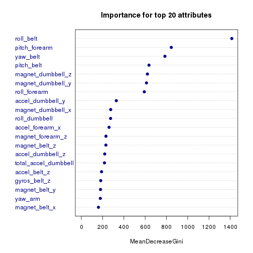

The next plot shows the error rates vs number of trees. As the number of trees increases the error rates decrease. The number of trees used in the analysis is 500. This number should not be too small to ensure that every input row gets predicted at least a few times.

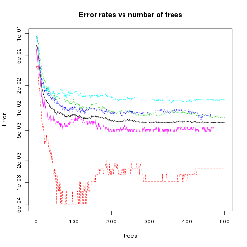

## Prediction

```r
predictions <- predict(modelFit, newdata=testData)
predictions
```

```
##  [1] B A B A A E D B A A B C B A E E A B B B
## Levels: A B C D E
```

## Conclusion

The model selected was able to predict the 100% of the 20 cases provided. The total number of 52 predictors could probably be reduced, but given the high accuracy and performance obtained with this model we decided it is not worth the effort.

## References

1. Groupware@LES - Human Activity Recognition
2. Random forests - The out-of-bag (oob) error estimate